# Where is My Data Going?

Connor MacLeod

March 19, 2016

# How bad is it really?

I decided to finally take on a problem for this assignment that’s been nagging at me for a long time. I always assumed that Windows used a lot more traffic at idle than my Ubuntu did, but I wanted to know exactly how much, and if I could reduce it somehow. I have already turned off every telemetry setting I could find, but I keep hearing rumors about Windows sending data anyways. So I came up with a plan.

On each OS do the following:

- Close all windows and non-essential programs in the tray (for Windows), like Skype, Steam, Dropbox, etc.
- Run Wireshark for 300s
- Filter down to only traffic from involving the host and do general data cleaning
- Import into R and start digging

## Step 1: Data Gathering

After running Wireshark on each OS, I have two csv files, ‘TakeHomeWindows.csv’ and ‘TakeHomeUbuntu.csv’. The next step is importing them into R.

```r
  windows <- read.csv("C:/Users/Connor/Documents/SRT411/TakeHomeWindows.csv")
  ubuntu <- read.csv("C:/Users/Connor/Documents/SRT411/TakeHomeUbuntu.csv")

  typeof(windows)
```

```
## [1] "list"
```

```r
  typeof(ubuntu)
```

```
## [1] "list"
```

As you can see, the variables are in list form. In order to be able to best work with them, it is ideal to put them in dplyr’s tbl_df format.

```r
  library(dplyr)
```

```r
  windf = tbl_df(data.frame(windows))
  ubndf = tbl_df(data.frame(ubuntu))
```

Ok, now we can begin cleaning this data to make it useful for us.

## Step 2: Cleaning Data

Let’s take a look at the data in it’s current state.

```r
  # Sample first 10 lines
  head(windf)
```

```
## Source: local data frame [6 x 7]
##
##     No.     Time            Source     Destination Protocol Length
##   (int)    (dbl)            (fctr)          (fctr)   (fctr)  (int)
## 1     1 0.000000     192.168.1.134 239.255.255.250     SSDP    369
## 2     2 0.039006 Cisco-Li_65:d1:20       Broadcast      ARP     42
## 3     3 0.101163     192.168.1.134 239.255.255.250     SSDP    369
## 4     4 0.207271     192.168.1.134 239.255.255.250     SSDP    378
## 5     5 0.309053     192.168.1.134 239.255.255.250     SSDP    378
## 6     6 0.413406     192.168.1.134 239.255.255.250     SSDP    433
## Variables not shown: Info (fctr)
```

```r
  head(ubndf)
```

```
## Source: local data frame [6 x 7]
##
##     No.     Time            Source   Destination Protocol Length
##   (int)    (dbl)            (fctr)        (fctr)   (fctr)  (int)
## 1     1 0.000000 AsustekC_bc:42:24     Broadcast      ARP     60
## 2     2 0.765025     192.168.1.100 192.168.1.255      UDP     63
## 3     3 0.766154     192.168.1.100 192.168.1.255      UDP     63
## 4     4 0.769730     192.168.1.135 192.168.1.255      UDP     63
## 5     5 0.770953     192.168.1.135 192.168.1.255      UDP     63
## 6     6 4.009094 AsustekC_bc:42:24     Broadcast      ARP     60
## Variables not shown: Info (fctr)
```

```r
  # Table stats
  str(windf)
```

```
## Classes 'tbl_df', 'tbl' and 'data.frame':    1308 obs. of  7 variables:
##  $ No.        : int  1 2 3 4 5 6 7 8 9 10 ...
##  $ Time       : num  0 0.039 0.101 0.207 0.309 ...
##  $ Source     : Factor w/ 34 levels "111.221.29.254",..: 12 28 12 12 12 12 12 12 11 12 ...
##  $ Destination: Factor w/ 37 levels "111.221.29.254",..: 19 30 19 19 19 19 19 19 21 19 ...
##  $ Protocol   : Factor w/ 15 levels "ARP","BROWSER",..: 12 1 12 12 12 12 12 12 13 12 ...
##  $ Length     : int  369 42 369 378 378 433 433 443 55 443 ...
##  $ Info       : Factor w/ 322 levels "[TCP Dup ACK 1117#1] 50089  >  443 [ACK] Seq=228 Ack=1461 Win=262144 Len=0 SLE=2921 SRE=4381",..: 291 321 291 291 291 291 291 291 42 291 ...
```

```r
  str(ubndf)
```

```
## Classes 'tbl_df', 'tbl' and 'data.frame':    960 obs. of  7 variables:
##  $ No.        : int  1 2 3 4 5 6 7 8 9 10 ...
##  $ Time       : num  0 0.765 0.766 0.77 0.771 ...
##  $ Source     : Factor w/ 14 levels "192.168.1.1",..: 8 2 2 5 5 8 8 2 2 5 ...
##  $ Destination: Factor w/ 17 levels "192.168.1.100",..: 13 3 3 3 3 13 13 3 3 3 ...
##  $ Protocol   : Factor w/ 12 levels "ARP","BROWSER",..: 1 12 12 12 12 1 1 12 12 12 ...
##  $ Length     : int  60 63 63 63 63 60 60 63 63 63 ...
##  $ Info       : Factor w/ 147 levels "[TCP Dup ACK 132#1] 32469 > 55412 [ACK] Seq=175 Ack=777 Win=66560 Len=0 TSval=368874839 TSecr=4294922451 SLE=344 SRE=777",..: 147 135 137 134 136 147 147 135 137 134 ...
```

So three things are immediately clear to me from this data. The first is that we have a superflous column. The ‘No.’ column is useless to us because R already provides a numbered column. The second is that there seems to be a lot of data picked up by Wireshark that doesn’t even involve our host IP (192.168.1.109). Finally, and the total run times are slightly different. So let’s fix all of those.

```r
  # Remove Column -> Only packets going to or coming from our host -> Ensure total run time is < 300s
  cleanpcap = function(tbldf){
    tbldf = tbldf %>%
      select(-No.) %>%
      filter(
        (Source == "192.168.1.109" | Destination == "192.168.1.109")
        & Time <= 300)
  }

  windat <- cleanpcap(windf)
  ubndat <- cleanpcap(ubndf)

  head(windat)
```

```
## Source: local data frame [6 x 6]
##
##       Time        Source   Destination Protocol Length
##      (dbl)        (fctr)        (fctr)   (fctr)  (int)
## 1 0.713152 192.168.1.109 24.156.131.29      TCP     55
## 2 0.741258 24.156.131.29 192.168.1.109      TCP     66
## 3 6.631118 192.168.1.109 24.156.131.98  TLSv1.2    144
## 4 6.631487 192.168.1.109 24.156.131.98  TLSv1.2    100
## 5 6.651011 24.156.131.98 192.168.1.109      TCP     60
## 6 6.651201 24.156.131.98 192.168.1.109      TCP     60
## Variables not shown: Info (fctr)
```

```r
  head(ubndat)
```

```
## Source: local data frame [6 x 6]
##
##       Time        Source     Destination Protocol Length
##      (dbl)        (fctr)          (fctr)   (fctr)  (int)
## 1 6.982354 192.168.1.109 239.255.255.250     SSDP    209
## 2 6.988411 192.168.1.100   192.168.1.109      UDP    381
## 3 6.988510 192.168.1.109 239.255.255.250   IGMPv2     46
## 4 7.037509 192.168.1.109   192.168.1.100      TCP     74
## 5 7.046852 192.168.1.100   192.168.1.109      TCP     74
## 6 7.046891 192.168.1.109   192.168.1.100      TCP     66
## Variables not shown: Info (fctr)
```

```r
  str(windat)
```

```
## Classes 'tbl_df', 'tbl' and 'data.frame':    511 obs. of  6 variables:
##  $ Time       : num  0.713 0.741 6.631 6.631 6.651 ...
##  $ Source     : Factor w/ 34 levels "111.221.29.254",..: 11 19 11 11 20 20 20 20 11 20 ...
##  $ Destination: Factor w/ 37 levels "111.221.29.254",..: 21 11 22 22 11 11 11 11 22 11 ...
##  $ Protocol   : Factor w/ 15 levels "ARP","BROWSER",..: 13 13 14 14 13 13 14 14 13 13 ...
##  $ Length     : int  55 66 144 100 60 60 100 181 66 149 ...
##  $ Info       : Factor w/ 322 levels "[TCP Dup ACK 1117#1] 50089  >  443 [ACK] Seq=228 Ack=1461 Win=262144 Len=0 SLE=2921 SRE=4381",..: 42 92 269 269 47 46 269 39 133 27 ...
```

```r
  str(ubndat)
```

```
## Classes 'tbl_df', 'tbl' and 'data.frame':    165 obs. of  6 variables:
##  $ Time       : num  6.98 6.99 6.99 7.04 7.05 ...
##  $ Source     : Factor w/ 14 levels "192.168.1.1",..: 3 2 3 3 2 3 3 3 2 3 ...
##  $ Destination: Factor w/ 17 levels "192.168.1.100",..: 9 2 9 1 2 1 9 1 2 1 ...
##  $ Protocol   : Factor w/ 12 levels "ARP","BROWSER",..: 10 12 6 11 11 11 10 3 11 11 ...
##  $ Length     : int  209 381 46 74 74 66 211 241 234 66 ...
##  $ Info       : Factor w/ 147 levels "[TCP Dup ACK 132#1] 32469 > 55412 [ACK] Seq=175 Ack=777 Win=66560 Len=0 TSval=368874839 TSecr=4294922451 SLE=344 SRE=777",..: 115 130 121 63 8 56 115 110 3 58 ...
```

> Just as I expected. Windows is using more than **Three Times** as much data as Ubunut (511 packets vs 165). Let’s see if we can track down what’s causing it.

## Step 3: Digging

```r
  library(ggplot2)
  library(grid)
  library(gridExtra)
```

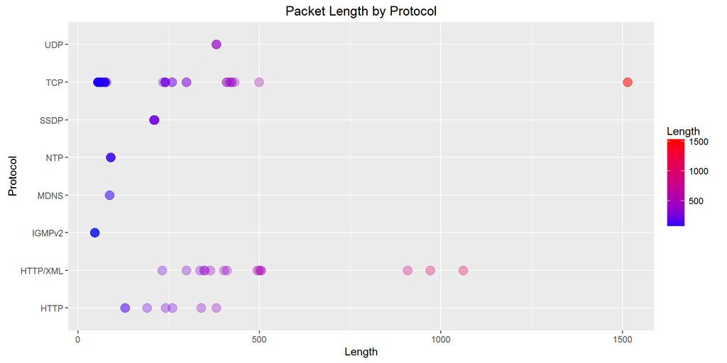

```r
  ulength <- ggplot(ubndat, aes(Length, Protocol)) +
    geom_point(aes(color = Length), size = 4, alpha = 1/3) +
    scale_color_gradient(low = "blue", high = "red") +
    ggtitle("Packet Length by Protocol")

  uproto <- ggplot(ubndat, aes(Protocol)) +
    geom_bar(fill = "steelblue") +
    ggtitle("Protocol Usage") +
    theme_light()

  uprolen <- ggplot(ubndat, aes(factor(Protocol), Length)) +
    geom_bar(stat = "identity", position = "stack", fill = "steelblue") +
    xlab("Protocol") +
    ylab("Total Length") +
    ggtitle("Total Data Sent By Protocol") +
    theme_light()

  utimeline <- qplot(Time, Length, data = ubndat, geom = "area") +
    geom_area(fill = "steelblue") +
    theme_light() +
    ylim(0, 400) +
    ggtitle("Packet Length Over Time")


  ulength
```

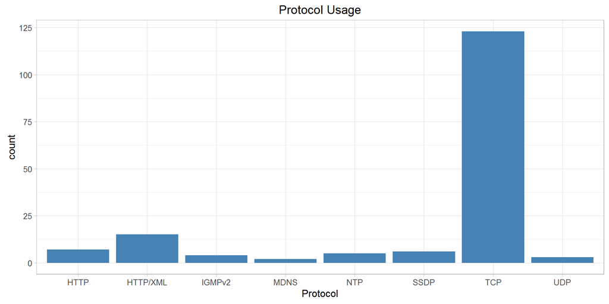

```r
  uproto
```

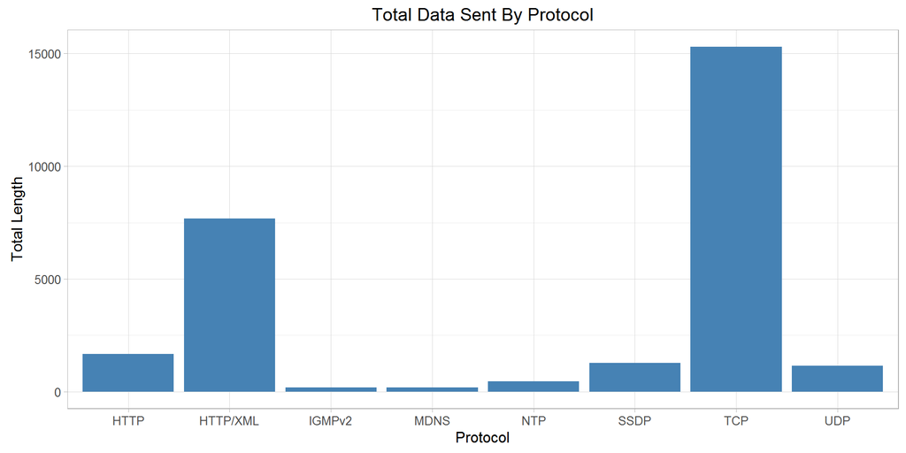

```r
  uprolen
```

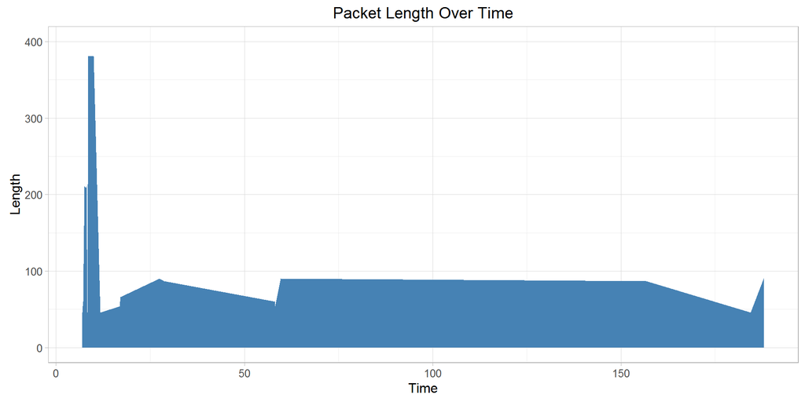

```r
  utimeline
```

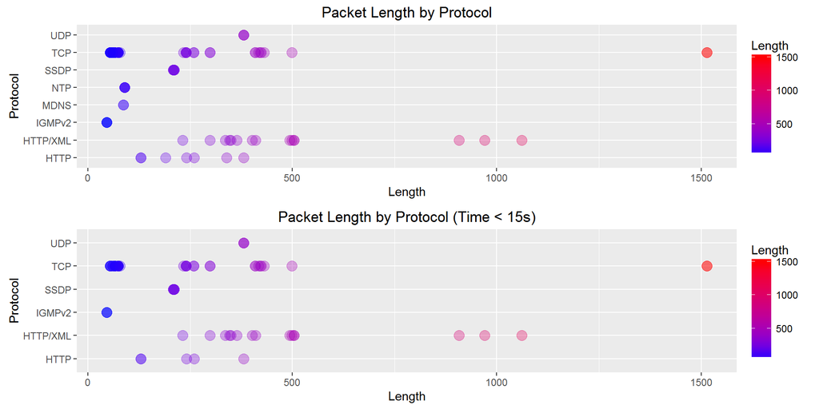

```r
  ulength2 <- ggplot(filter(ubndat, Time < 15), aes(Length, Protocol)) +
    geom_point(aes(color = Length), size = 4, alpha = 1/3) +
    scale_color_gradient(low = "blue", high = "red") +
    ggtitle("Packet Length by Protocol (Time < 15s)")

  grid.arrange(ulength, ulength2, ncol = 1)
```

So as we can see, most of it looks the same. So the conclusion here is that the rest of the data after the intial burst was all of the other protocols we see.

My guess as to the source of this traffic spike is that I ran wireshark immediately after booting into Ubunut to minimise background processes. This means that if anything runs on startup, wireshark would have caught the tail end of that, so in reality, the idle traffic is actually everything post 15s.

[figure not shown]

```r
  ggplot(filter(ubndat, Time > 15), aes(Length, Protocol)) +
    geom_point(aes(color = Length), size = 4, alpha = 1/3) +
    scale_color_gradient(low = "blue", high = "red") +
    ggtitle("Packet Length by Protocol (Time < 15s)")
```

> Wow. That’s impressive, very little traffic at all. Let’s see how Windows stands up.

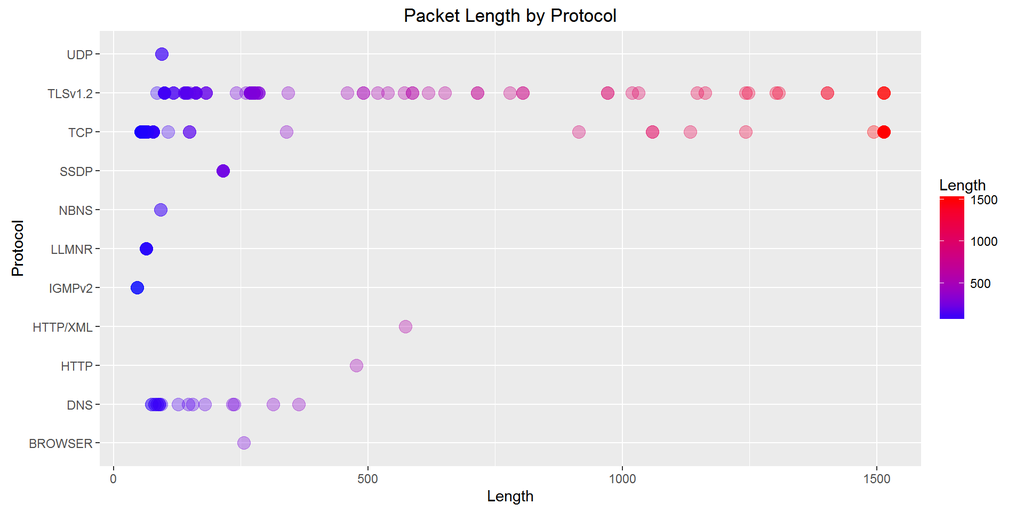

```r
  wlength <- ggplot(windat, aes(Length, Protocol)) +
    geom_point(aes(color = Length), size = 4, alpha = 1/3) +
    scale_color_gradient(low = "blue", high = "red") +
    ggtitle("Packet Length by Protocol")

  wproto <- ggplot(windat, aes(Protocol)) +
    geom_bar(fill = "steelblue") +
    ggtitle("Protocol Usage") +
    theme_light()

  wprolen <- ggplot(windat, aes(factor(Protocol), Length)) +
    geom_bar(stat = "identity", position = "stack", fill = "steelblue") +
    xlab("Protocol") +
    ylab("Total Length") +
    ggtitle("Total Data Sent By Protocol") +
    theme_light()

  wtimeline <- qplot(Time, Length, data = windat, geom = "area") +
    geom_area(fill = "steelblue") +
    theme_light() +
    ylim(0, 400) +
    ggtitle("Packet Length Over Time")


  wlength
```

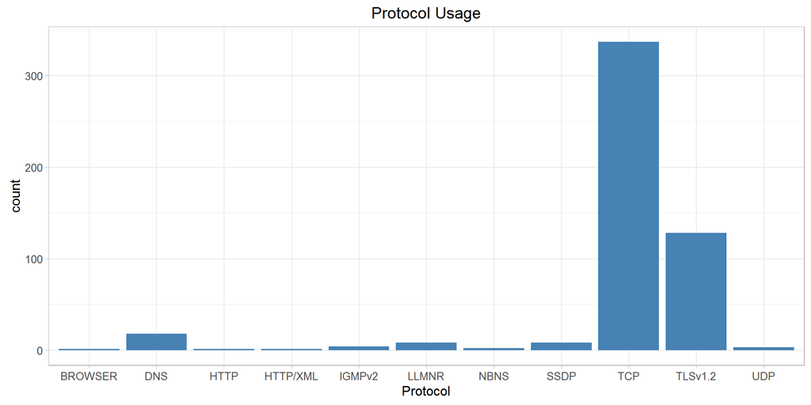

```r
  wproto
```

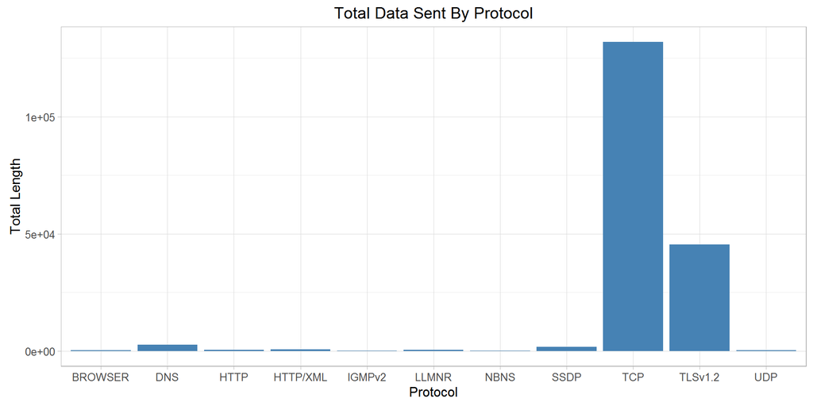

```r
  wprolen
```

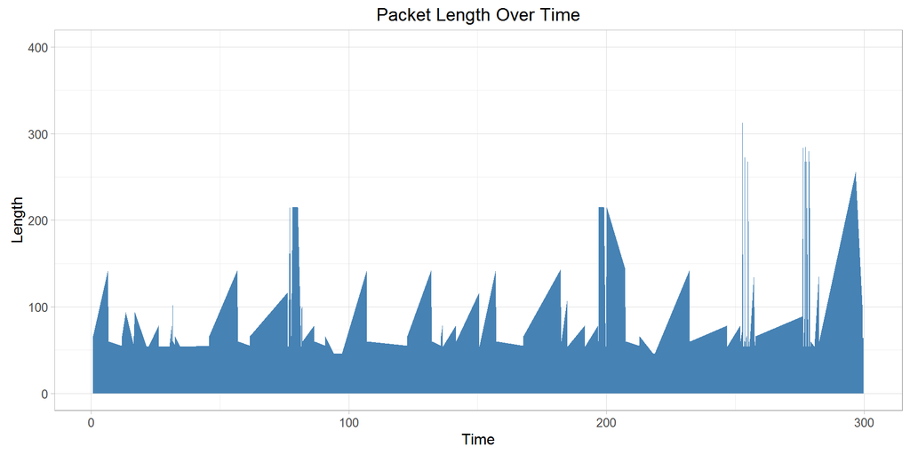

```r
  wtimeline
```

## Step 4: The Cause

Let’s start by just isolating TCP and TLS, since they are oviously the problem here.

```r
  # Get Sources for the biggest TCP and TLS packets
  wins <- windat %>%
    filter(Protocol == "TCP" | Protocol == "TLSv1.2") %>%
    arrange(desc(Length), Source)
```

I am going to venture a guess and assume that it’s only a handful of IP’s causing this. Let’s isolate them and see.

```r
  # Get list of source IP's using big packets
  wins <- wins %>%
    filter(Length > 1400, Source != "192.168.1.109")

  unique(wins$Source)
```

```
## [1] 111.221.29.254  13.107.5.88     131.253.61.66   134.170.108.200
## [5] 137.116.74.190  23.99.116.116   40.121.144.182
## 34 Levels: 111.221.29.254 13.107.5.88 131.253.61.66 ... fe80::ffff:ffff:fffe
```

> So those are the big bad IP’s that are ruining my network. Here’s what I could get on them.

| IP | Details | Domain |
| --- | --- | --- |
| 111.221.29.254 | Microsoft Corp, Singapore | vortex-win.data.microsoft.com |
| 13.107.5.88 | Microsoft Azure, US | e-0009.e-msedge.net |
| 131.253.61.66 | Microsoft Corp, US | N/A |
| 134.170.108.200 | Microsoft Corp, US | by3302-e.1drc.com |
| 137.116.74.190 | Microsoft Corp, US | N/A |
| 23.99.116.116 | Microsoft Azure, Hong Kong | N/A |
| 40.121.144.182 | Microsoft Acure, US | N/A |

Ugh. Well that sucks. All of the biggest packet hogs are Microsoft demanding my data. If there was ever a reason to switch to a Linux or FreeBSD dsitro, this is it.

“But what if something is genreating a ton of smaller packets instead of a few large packets?” Good question, let’s see.

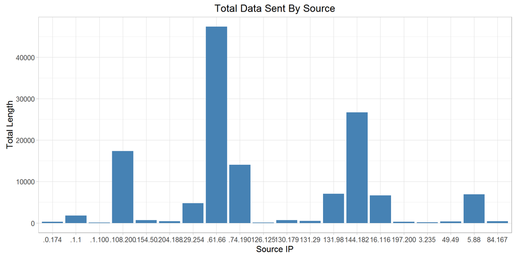

```r
  wins <- windat %>%
    filter(Source != "192.168.1.109") %>%
    mutate(Labels = substr(Source, 8, 15))

  ggplot(wins, aes(factor(Labels), Length)) +
    geom_bar(stat = "identity", position = "stack", fill = "steelblue") +
    xlab("Source IP") +
    ylab("Total Length") +
    ggtitle("Total Data Sent By Source") +
    theme_light()
```

> And still, our culprits are (in order): 131.253.61.66, 40.121.144.182, 134.170.108.200, 137.116.74.190

> AKA Micosoft